# Data Analysis of High School Attitudinal Survey

## Chi-sq statistic helps us understand the deviations

```r
# use output in x.summary and create table
x.table <- data.frame(n.Studen = frame.Studen$n.Studen
                    , obs = x.summary$observed
                    , exp = x.summary$expected
                    , res = x.summary$residuals
                    , chisq = x.summary$residuals^2
                    , stdres = x.summary$stdres)
x.table
```

```
  n.Studen  obs       exp       res      chisq    stdres
1    HC,NW  844  572.4123 11.351564 128.857999 12.348561
2    LC,NW  754  992.4278 -7.568460  57.281581 -8.850089
3     HC,W 1010 1106.8232 -2.910316   8.469939 -3.477567
4     LC,W 1086 1022.3367  1.991095   3.964458  2.341259
```

```r
# p1... ^^ p versus p1 >>
x.table1 <- data.frame(n.Studen1 = frame.Studen1$n.Studen1
                    , obs = x.summary1$observed
                    , exp = x.summary1$expected
                    , res = x.summary1$residuals
                    , chisq = x.summary1$residuals^2
                    , stdres = x.summary1$stdres)
x.table1
```

```
  n.Studen1  obs       exp       res     chisq    stdres
1     HC,NW  844 2141.6901 -28.04095  786.2947 -43.25655
2     LC,NW  754 1095.1710 -10.30935  106.2826 -12.29110
3      HC,W 1010  355.4312  34.71983 1205.4665  36.52127
4      LC,W 1086  101.7077  97.59942 9525.6462  98.97143
```

Plot observed vs expected values to help identify `n.Studen` groups that deviate the most. Plot contribution to chi-square values to help identify `n.Studen` groups that deviate the most. The term ``Contribution to Chi-Square'' (`chisq`) refers to the values of $\frac{(O-E)^2}{E}$ for each category. $\chi^2_{\textrm{s}}$ is the sum of those contributions.

```r
library(reshape2)
x.table.obsexp <- melt(x.table,
              # id.vars: ID variables
              #   all variables to keep but not split apart on
              id.vars = c("n.Studen"),
              # measure.vars: The source columns
              #   (if unspecified then all other variables are measure.vars)
              measure.vars = c("obs", "exp"),
              # variable.name: Name of the destination column identifying each
              #   original column that the measurement came from
              variable.name = "stat",
              # value.name: column name for values in table
              value.name = "value"
            )
x.table.obsexp
```

```
  n.Studen stat     value
1    HC,NW  obs  844.0000
2    LC,NW  obs  754.0000
3     HC,W  obs 1010.0000
4     LC,W  obs 1086.0000
5    HC,NW  exp  572.4123
6    LC,NW  exp  992.4278
7     HC,W  exp 1106.8232
8     LC,W  exp 1022.3367
```

```r
# p1... ^^ p versus p1 >> >>
x.table.obsexp1 <- melt(x.table1,
              # id.vars: ID variables
              #   all variables to keep but not split apart on
              id.vars = c("n.Studen1"),
              # measure.vars: The source columns
              #   (if unspecified then all other variables are measure.vars)
              measure.vars = c("obs", "exp"),
              # variable.name: Name of the destination column identifying each
              #   original column that the measurement came from
              variable.name = "stat",
              # value.name: column name for values in table
              value.name = "value"
              )
x.table.obsexp1
```

```
  n.Studen1 stat     value
1     HC,NW  obs  844.0000
2     LC,NW  obs  754.0000
3      HC,W  obs 1010.0000
4      LC,W  obs 1086.0000
5     HC,NW  exp 2141.6901
6     LC,NW  exp 1095.1710
7      HC,W  exp  355.4312
8      LC,W  exp  101.7077
```

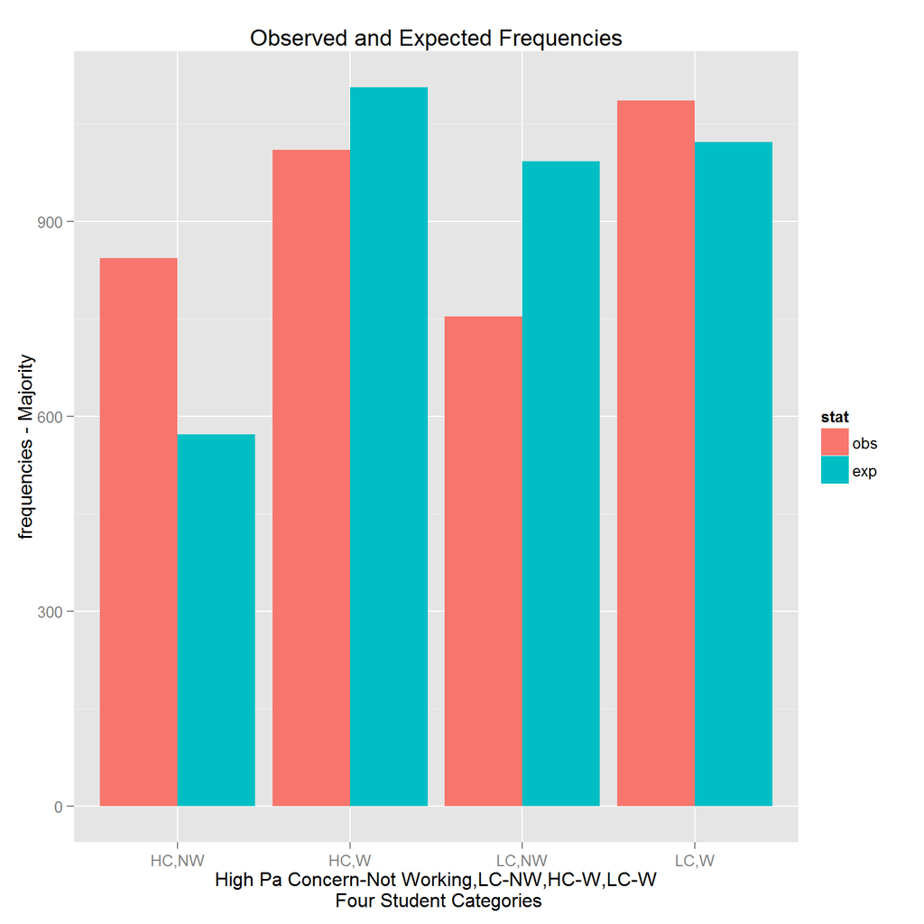

```r
# Observed vs Expected counts
library(ggplot2)
p <- ggplot(x.table.obsexp, aes(x = n.Studen, fill = stat, weight=value))
p <- p + geom_bar(position="dodge")
p <- p + labs(title = "Observed and Expected Frequencies", x = "High Pa Concern-Not Working,LC-NW,HC-W,LC-W\n Four Student Categories", y = "frequencies - Majority")
print(p)
```

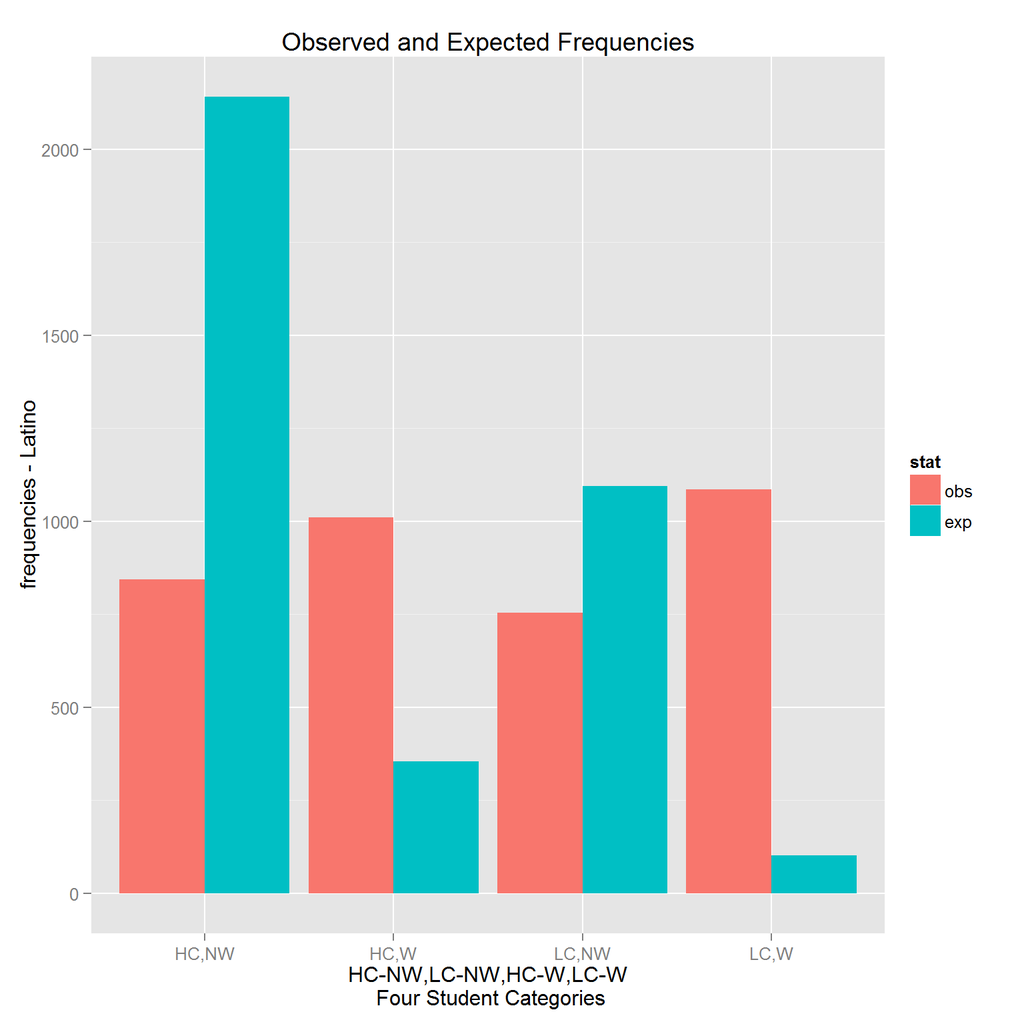

```r
# p1... ^^ p versus p1 >> >>
p1 <- ggplot(x.table.obsexp1, aes(x = n.Studen1, fill = stat, weight=value))
p1 <- p1 + geom_bar(position="dodge")
p1 <- p1 + labs(title = "Observed and Expected Frequencies", x = "HC-NW,LC-NW,HC-W,LC-W\n Four Student Categories", y = "frequencies - Latino")
print(p1)
```

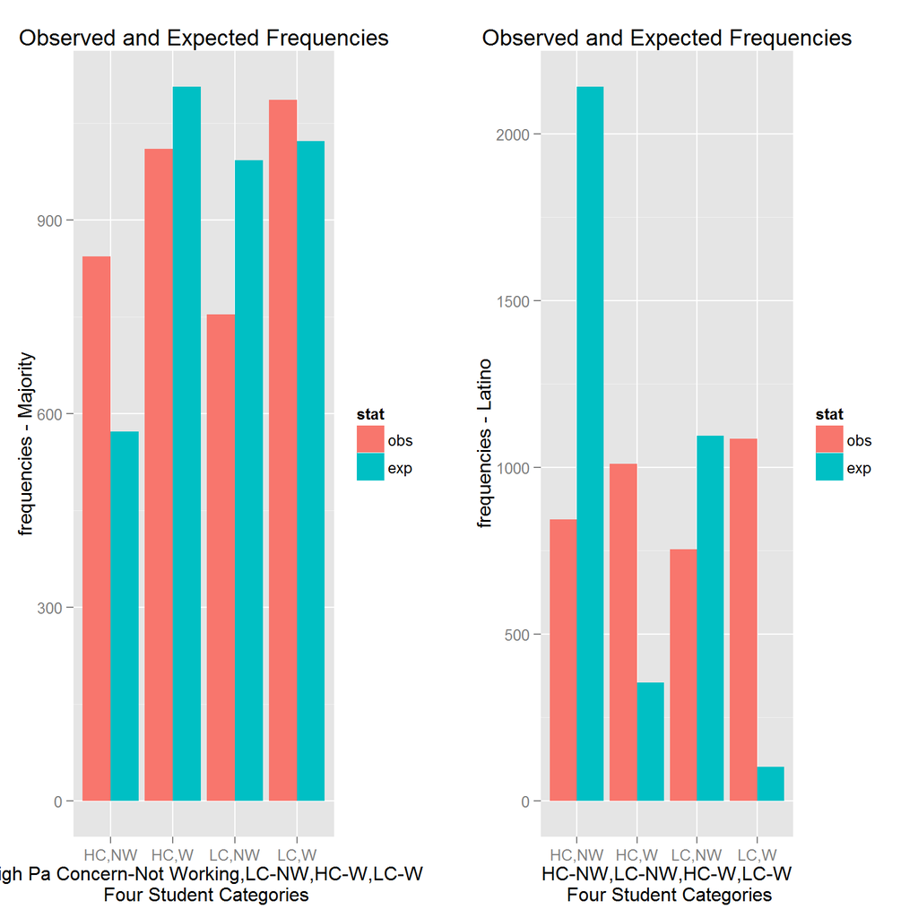

```r
library(gridExtra)
grid.arrange(p, p1, nrow=1)
```

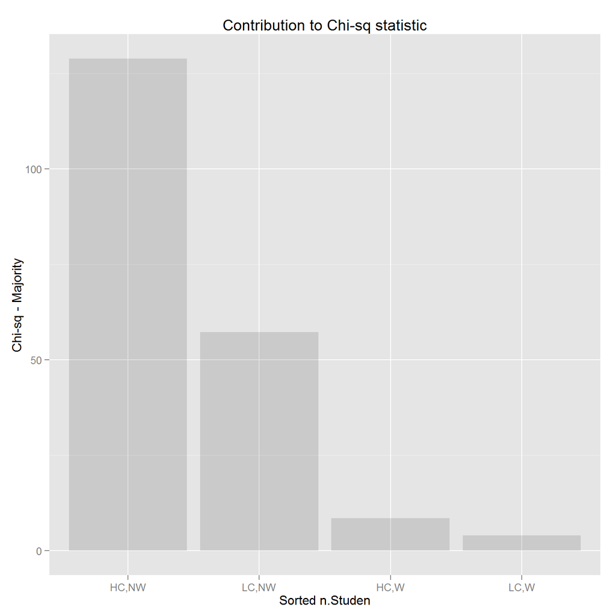

```r
 # Contribution to chi-sq
# pull out only the n.Studen and chisq columns
x.table.chisq <- x.table[, c("n.Studen", "chisq")]
# reorder the n.Studen categories to be descending relative to the chisq statistic
x.table.chisq$n.Studen <- with(x.table, reorder(n.Studen, -chisq))
# p1... ^^ p versus p1 >> >>
x.table.chisq1 <- x.table1[, c("n.Studen1", "chisq")]
# reorder the n.Studen categories to be descending relative to the chisq statistic
x.table.chisq1$n.Studen1 <- with(x.table1, reorder(n.Studen1, -chisq))


p3 <- ggplot(x.table.chisq, aes(x = n.Studen, weight = chisq))
p3 <- p3 + geom_bar(alpha = .15)
p3 <- p3 + labs(title = "Contribution to Chi-sq statistic")
p3 <- p3 + xlab("Sorted n.Studen")
p3 <- p3 + ylab("Chi-sq - Majority")
print(p3)
```

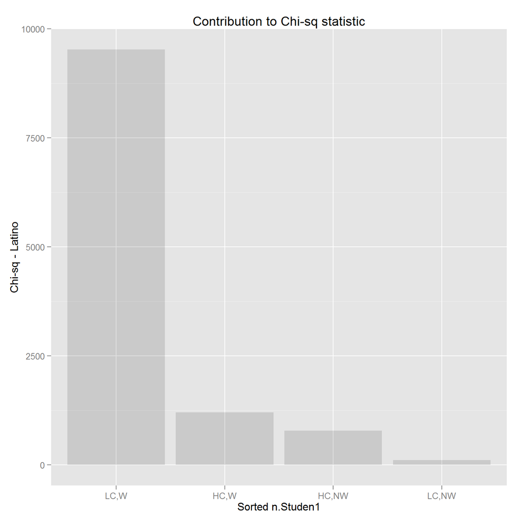

```r
# p1... ^^ p versus p1 >> >>
p4 <- ggplot(x.table.chisq1, aes(x = n.Studen1, weight = chisq))
p4 <- p4 + geom_bar(alpha = .15)
p4 <- p4 + labs(title = "Contribution to Chi-sq statistic")
p4 <- p4 + xlab("Sorted n.Studen1")
p4 <- p4 + ylab("Chi-sq - Latino")
print(p4)
```

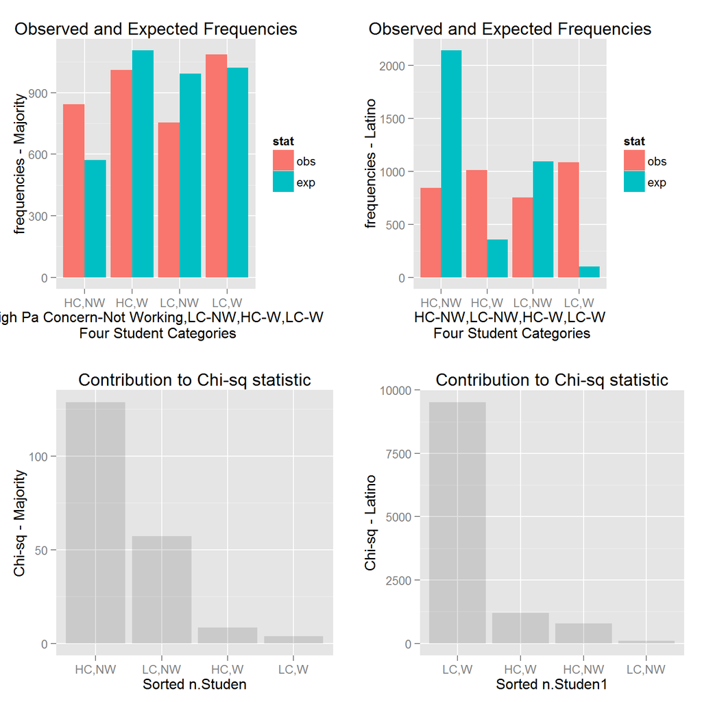

```r
library(gridExtra)
grid.arrange(p, p1,p3,p4, nrow=2)
```

## Multiple Comparisons

The goodness-of-fit test suggests that at least one of the `n.Studen` category type proportions for the observed number of student types differs from the expected number of student type proportions. A reasonable next step in the analysis would be to **separately** test the four hypotheses: $H_0: p_{4} = 0.155$, $H_0: p_{5} = 0.269$, $H_0: p_{6} = 0.3$, and $H_0: p_{7} = 0.277$ to see which `n.Studen` types led to this conclusion.

A Bonferroni comparison with a Family Error Rate $\alpha=0.05$ sets each test’s significance level to $\alpha = 0.05 / 4 = 0.0125$, which corresponds to 98.75% two-sided CIs for the individual proportions.

Below I perform exact binomial tests of proportion for each of the four `n.Student` category types at the Bonferroni-adjusted significance level.I save the p-values and confidence intervals in a table along with the observed and census proportions in order to display the table below.

```r
b.sum1 <- binom.test(frame.Studen$obs[1], sum(frame.Studen$obs), p = frame.Studen$exp.prop[1], alternative = "two.sided", conf.level = 1-0.05/4)
b.sum2 <- binom.test(frame.Studen$obs[2], sum(frame.Studen$obs), p = frame.Studen$exp.prop[2], alternative = "two.sided", conf.level = 1-0.05/4)
b.sum3 <- binom.test(frame.Studen$obs[3], sum(frame.Studen$obs), p = frame.Studen$exp.prop[3], alternative = "two.sided", conf.level = 1-0.05/4)
b.sum4 <- binom.test(frame.Studen$obs[4], sum(frame.Studen$obs), p = frame.Studen$exp.prop[4], alternative = "two.sided", conf.level = 1-0.05/4)
# put the p-value and CI into a data.frame
b.sum  <- data.frame(
            rbind( c(b.sum1$p.value, b.sum1$conf.int)
                 , c(b.sum2$p.value, b.sum2$conf.int)
                 , c(b.sum3$p.value, b.sum3$conf.int)
                 , c(b.sum4$p.value, b.sum4$conf.int)
            )
          )
names(b.sum) <- c("p.value", "CI.lower", "CI.upper")
b.sum$n.Studen <- frame.Studen$n.Studen
b.sum$Observed <- x.table$obs/sum(x.table$obs)
b.sum$exp.prop <- frame.Studen$exp.prop
b.sum
```

```
       p.value  CI.lower  CI.upper n.Studen  Observed  exp.prop
1 1.315211e-31 0.2114297 0.2461947    HC,NW 0.2284786 0.1549573
2 9.493957e-20 0.1877855 0.2211714    LC,NW 0.2041148 0.2686594
3 4.921963e-04 0.2552504 0.2921387     HC,W 0.2734164 0.2996273
4 2.049316e-02 0.2753936 0.3130926     LC,W 0.2939903 0.2767560
```

(2 p) Conclusions of the four hypothesis tests above. (Note that the p-value is your guide here, not the CI.)

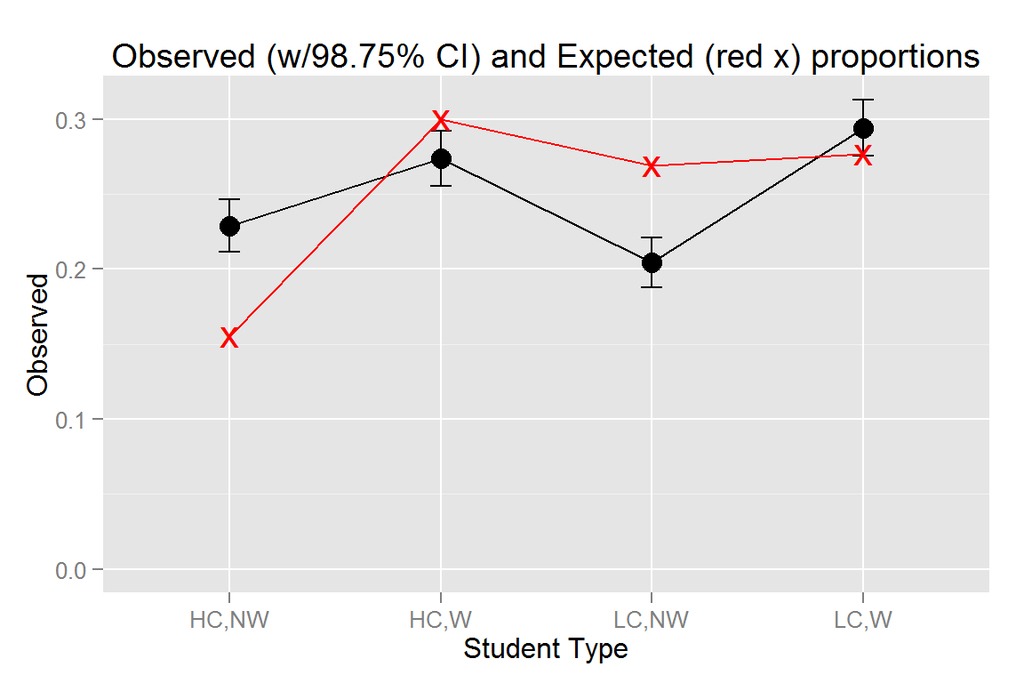

```r
# Observed vs Expected proportions
library(ggplot2)
p <- ggplot(b.sum, aes(x = n.Studen, y = Observed))
# observed
p <- p + geom_point(size = 4)
p <- p + geom_line(aes(group = 1))
p <- p + geom_errorbar(aes(ymin = CI.lower, ymax = CI.upper), width = 0.1)
# expected
p <- p + geom_point(aes(y = exp.prop), colour = "red", shape = "x", size = 6)
p <- p + geom_line(aes(y = exp.prop, group = 1), colour = "red")
p <- p + labs(title = "Observed (w/98.75% CI) and Expected (red x) proportions")
p <- p + xlab("Student Type")
p <- p + expand_limits(y = 0)
print(p)
```

10 Conclusion: Multinomial Tests and Goodness of Fit 1. Using a categorical variable with three to five levels (or a categorical variable you can reduce to three to five levels), specify an multinomial goodness-of-fit hypothesis associated with your research questions. * (1 p) Specify the goodness-of-fit hypotheses in words and notation, * (2 p) plot the data in a way that is consistent with hypothesis test (comparing observed and expected proportions), * (1 p) use `chisq.test()` to calculate the hypothesis test statistic and p-value, * (1 p) state the significance level, test statistic, and p-value, * (1 p) state the conclusion in the context of the problem, and * (1 p) assess the assumptions of the test. * (1 p) Plot the contribution to Chi-sq statistic and comment on which groups deviate the most from expected. * (2 p) If you rejected the goodness-of-fit null hypothesis, perform follow-up pairwise comparisons using one-sample proportions tests to indicate which groups have statistically different proportions (using Bonferroni to control the Familywise Error Rate) and summarize the results. Otherwise, simply indicate that you did not reject the null hypothesis.

# 11 Two-way categorical analysis Homogeneity of Proportions and Simple Linear Regression

1. Two-way categorical analysis. Using two categorical variables with two to five levels each, specify a hypothesis test for homogeneity of proportions associated with your research questions.
   - (1 p) Specify the hypotheses in words and notation.
   - (1 p) State the conclusion of the test in the context of the problem.
   - (1 p) Plot a mosaic plot of the data and Pearson residuals.
   - (1 p) Interpret the mosaic plot with reference to the Pearson residuals.
2. Simple linear regression. Select two numerical variables.
   - (1 p) Plot the data and, if required, transform the variables so a roughly linear relationship is observed. All interpretations will be done on this scale of the variables.
   - (0 p) Fit the simple linear regression model.
   - (1 p) Assess the residuals for lack of fit (interpret plots of residuals vs fitted and $x$-value).
   - (1 p) Assess the residuals for normality (interpret QQ-plot and histogram).
   - (1 p) Assess the relative influence of points.
   - (1 p) Test whether the slope is different from zero, $H_A: \beta_1 \ne 0$.
   - (1 p) Interpret the $R^2$ value.

## Hypothesis test for Homogeneity of Proportions (categorical association)

- (1 p) Specify the hypotheses in words and notation. **null and alternative hypotheses** in words and notation.
  - In words: ``There is an association between [Working Status] and [ExpectCollege].’’
  - In notation: $H_0: p(i-College Expectation \textrm{ and } j-Working Status) = p(i)p(j)$ versus $H_A: p(i-College Expectation \textrm{ and } j-Working Status) \ne p(i)p(j)$, for all row categories $i$ and column categories $j$. The probability of row category, College Expectation, $i$ are conditional on column category, Working Status $j$, $p(i|j) = p(i)$, does not depend on which column category $j$ we consider.

**significance level** of the test is $\alpha=0.05$. * (1 p) State the conclusion of the test in the context of the problem.

**Check assumptions** of the test: The expected count for each cell is at least 5

## sum of the frequencies and column proportions.

The column proportions are interpreted as the proportion of students’ College Expectations conditional on Working Status. If these column proportions are roughly the same for each Grade, then that’s an indication of no association.

```r
# Tabulate by two categorical variables:
tab.ExpectCollegeWorking <- xtabs(~ ExpectCollege + Working, data = addhealth.sub)
tab.ExpectCollegeWorking
```

```
             Working
ExpectCollege Not Working Working
            1          76      77
            2          56      79
            3         195     265
            4         339     430
            5         932    1245
```

```r
# column proportions
prop.table(tab.ExpectCollegeWorking, margin = 2)
```

```
             Working
ExpectCollege Not Working    Working
            1  0.04755945 0.03673664
            2  0.03504380 0.03769084
            3  0.12202753 0.12643130
            4  0.21214018 0.20515267
            5  0.58322904 0.59398855
```

```r
chisq.gg <- chisq.test(tab.ExpectCollegeWorking, correct=FALSE)
chisq.gg
```

```
    Pearson's Chi-squared test

data:  tab.ExpectCollegeWorking
X-squared = 3.27, df = 4, p-value = 0.5137
```

```r
  # names(chisq.gg) for the objects to report
```

```r
# table of expected frequencies:
chisq.gg$expected
```

```
             Working
ExpectCollege Not Working    Working
            1    66.18679   86.81321
            2    58.40011   76.59989
            3   198.99296  261.00704
            4   332.66432  436.33568
            5   941.75582 1235.24418
```

```r
# smallest expected frequency:
min(chisq.gg$expected)
```

```
[1] 58.40011
```

```r
# The Pearson residuals
chisq.gg$residuals
```

```
             Working
ExpectCollege Not Working    Working
            1   1.2062170 -1.0532178
            2  -0.3140682  0.2742311
            3  -0.2830585  0.2471548
            4   0.3473682 -0.3033073
            5  -0.3179030  0.2775795
```

```r
# The sum of the squared residuals is the chi-squared statistic:
chisq.gg$residuals^2
```

```
             Working
ExpectCollege Not Working    Working
            1  1.45495957 1.10926784
            2  0.09863885 0.07520271
            3  0.08012214 0.06108549
            4  0.12066468 0.09199531
            5  0.10106232 0.07705038
```

```r
sum(chisq.gg$residuals^2)
```

```
[1] 3.270049
```

The mosaic plot is a visual representation of the observed frequencies (areas of each box) and the Pearson residual (color bar). If rectangles are the same size along rows and columns (and gray), then they’re close to expected. Differences between observed and expected frequencies are indicated by different sized rectangles across rows or down columns and colors indicate substantial contributions to the $X^2$ statistic.

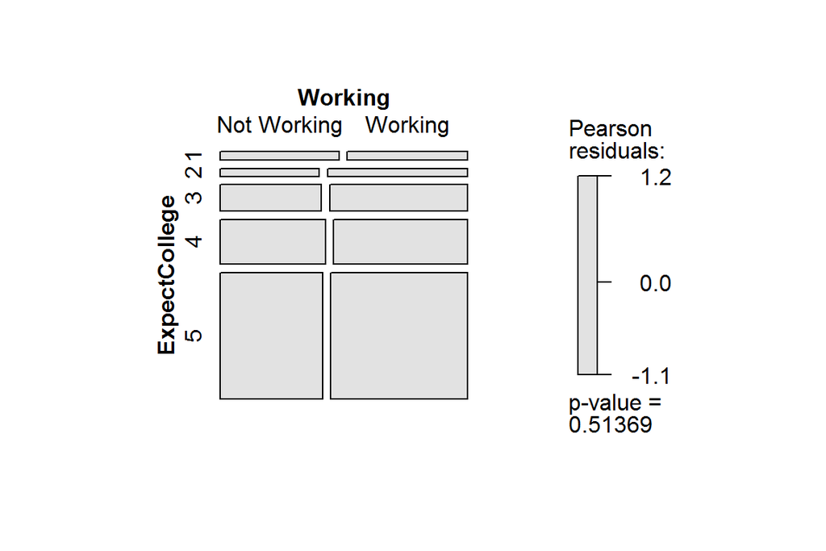

```r
# mosaic plot
#install.packages("vcd")
library(vcd)
mosaic(tab.ExpectCollegeWorking, shade=TRUE, legend=TRUE)
```

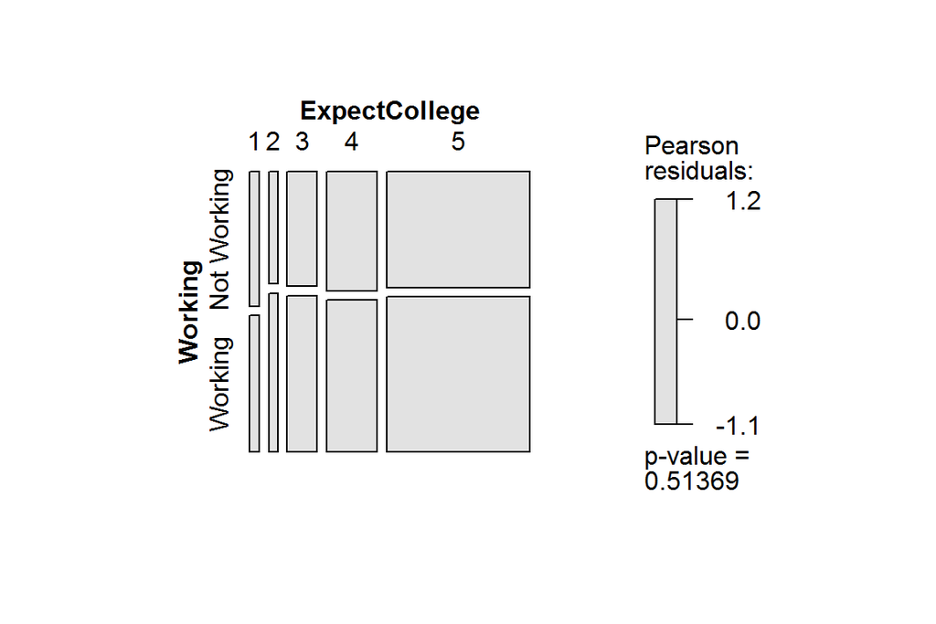

```r
# this layout gives us the interpretation we want:
mosaic(~ ExpectCollege + Working, data = addhealth.sub, shade=TRUE, legend=TRUE, direction = "v")
```